| National Park Service U.S. Department of the Interior Natural Resource Stewardship and Science |  |
| --- | --- |

# NCBN Thermal Report

2026-05-05

## Eelgrass Importance and Vulnerability

Eelgrass (Zostera marina) is a foundational marine plant that supports healthy coastal ecosystems. It improves water quality, stabilizes sediments, provides habitat for fish and invertebrates, and acts as a globally important carbon sink (Novak et al. 2023). When eelgrass meadows decline, the carbon they store can be released back into the water column (Berger et al. 2024). Because eelgrass responds quickly to changes in its environment, it is often considered a “canary in the coal mine” for coastal health (Orth et al. 2006). Its ecological significance is one reason the Northeast Coastal and Barrier Network (NCBN) monitors seagrass conditions over time, especially as concerns rise about the effects of warming waters.

In recent decades, eelgrass along the Northeast U.S. coast has experienced water temperatures that approach or exceed known physiological limits. When water becomes too warm, eelgrass respiration increases faster than photosynthesis, creating stress on the plants. Studies show that temperatures above 25 °C increase the likelihood of eelgrass mortality, and sustained exposure above 30 °C has led to complete die offs in areas such as Chesapeake Bay (Jarvis & Moore 2010; Plaisted et al. 2022, Novak et al. 2023). Long term temperature records from New Hampshire to Maryland indicate that warmer summers are consistently followed by lower eelgrass presence in the next year (Plaisted et al. 2022). Temperature stress is also more severe when combined with poor water clarity, low light, or high nutrient levels. Repeated hot summers without adequate recovery time can lead to large scale declines.

These patterns align with broader climate driven trends. Marine heatwaves, periods when water temperatures exceed the 90th percentile of a 30 year baseline, have become more frequent and more intense (Berger et al. 2024). Such events have already affected corals, kelp forests, and seagrasses worldwide. Research shows that eelgrass meadows experiencing both high heat and little cooling tend to lose shoot density and canopy height, while sites that receive periodic cooling are better able to recover between heat events (Berger et al. 2024).

Other marine systems use cumulative heat stress metrics to understand these risks. NOAA’s Degree Heating Weeks (DHW) index, for example, tracks how much and how long temperatures exceed thresholds that lead to coral bleaching and mortality (Skirving et al. 2020). These tools emphasize that it is the accumulation of heat over time, not single temperature spikes, that often drives ecosystem decline. This same concept is directly relevant to eelgrass.

Calculating cumulative stress frameworks requires long term temperature datasets and NCBN continuous monitoring program does exactly that. To better understand how warming affects eelgrass within the Northeast Coastal and Barrier Network, we used long term temperature datasets to:

1. Identify years with extreme heat and low cooling,
2. Determine where these conditions overlapped to create compounded “stress years,” and
3. Compare patterns across parks to understand regional vulnerability.

# Methods

## Protocol

The Northeast Coastal and Barrier Network uses a standardized Estuarine Nutrient Enrichment monitoring protocol (Kopp and Neckles, 2009) that includes seagrass condition monitoring (SOP 9). Seagrass condition is characterized using measures of population and shoot structure to track how meadows change. This protocol was developed from the international SeagrassNet program that provides framework for standardzied seagrass monitoring worldwide.

Within the network, three coastal parks, Assateague Island (ASIS), Fire Island (FIIS), and Cape Cod (CACO) implement the seagrass monitoring protocol.Seagrass condition is monitored across three permanent 50-m transects that run parallel to shore at a shallow, mid-depth, and deep depth. Temperature loggers are attached to each transect to record continuous water temperature data collected once a year. These longterm records give us on the ground data to observe the thermal environment expereinced by eelgrass meadows.

For this analysis, we used the continuous water temperature data and focused on the months from May-September to hone in on when thermal stress likely occurs. To ensure data quality in each sampling year, we only include years with 80 percentage data coverage and with at least 10 days of data in three of five months.From this dataset we examined patterns of thermal stress and cooling dynamics with the goal to compare the conditions at CACO with those at other long-term National Park Service monitoring sites.

Available datasets for each site in CACO after data filters were applied.

| Park Code | Site Name | Years of Data |
| --- | --- | --- |
| CACO | Duck Harbor | 20 |
| CACO | East Harbor | 2 |
| CACO | Pleasant Bay | 21 |
| CACO | Provincetown Harbor | 2 |

## Novel Thermal Metrics for Eelgrass

To describe long-term thermal conditions in eelgrass meadows, we calculate two metrics from our continuous water temperature record: **heating degree hours (HDH)** and **cooling degree hours (CDH)**. Following the methods outlined by Berger et al. 2024, these metrics capture not just how hot the water gets, but how long water temperatures remain above or below a biological threshold.

For eelgrass, prolonged exposure to high temperatures can lead to physiological stress where respiration outpaces photosynthesis. We applied a threshold of 25 °C for northern sites and 28.6 °C for southern sites, values associated with known limits in eelgrass thermal tolerance.

Together, HDH and CDH show how often heat stress events occur and how well the area recovers from them. Looking at both gives us a clearer picture of the factors that shape eelgrass resilience.

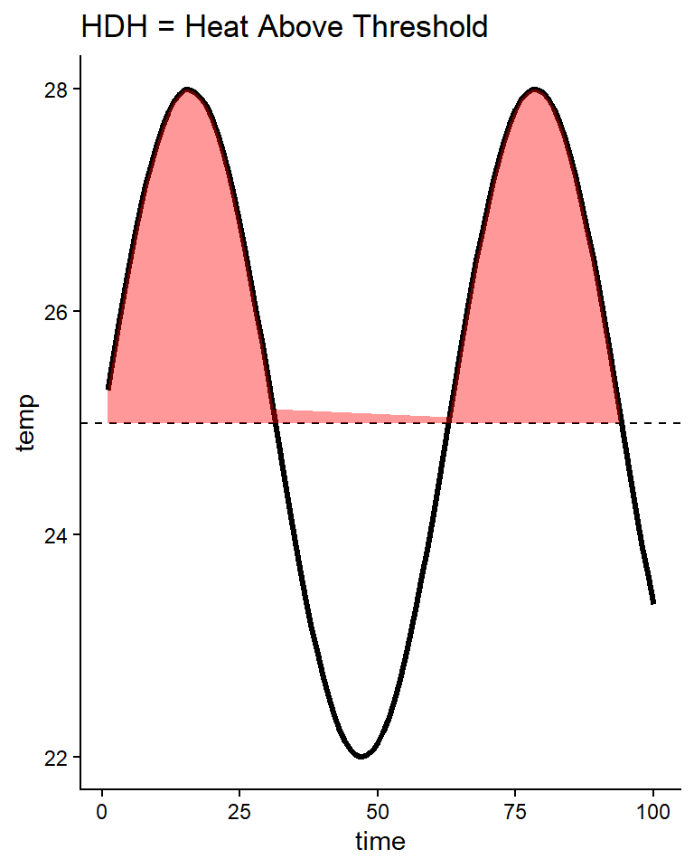

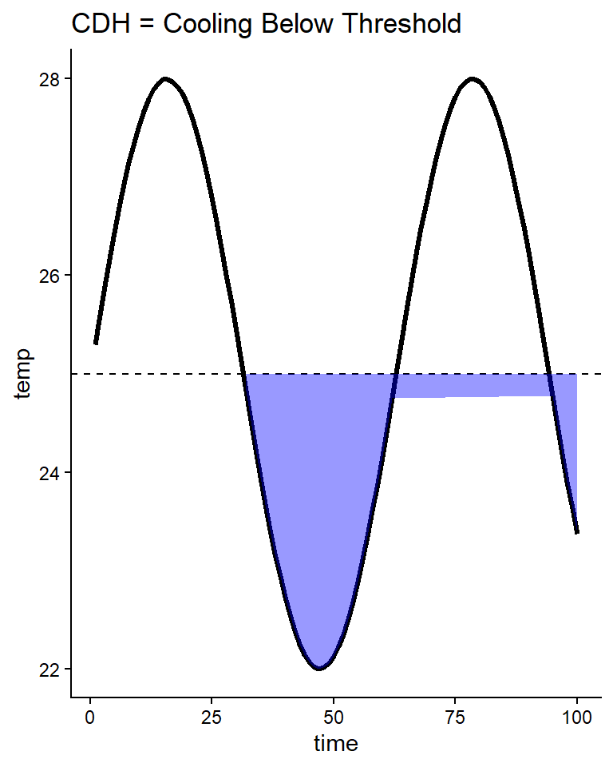

# Results

At CACO, the long‑term monitoring site(s) include **Duck Harbor, Pleasant Bay**, with 21 years of data collected between 2004 and 2024. Additional points of interest were included in the analysis to provide broader ecological context but are not included in long‑term monitoring protocol.

## Extreme Heat Years

At CACO, we identified extreme heat years for each long-term monitoring site by calculating the 90th percentiles of heating degree hours (HDH) as a site-specific threshold. The red points indicated years where the mean HDH exceeded this threshold and are considered “extreme heat years” for that site. These years represent years when the eelgrass meadow at these sites experiences the more intense and prolonged thermal stress. The table below lists years at each moitoring locations when heat degree around were exceptionally high (i.e, HDH above the 90th percentile for that site).

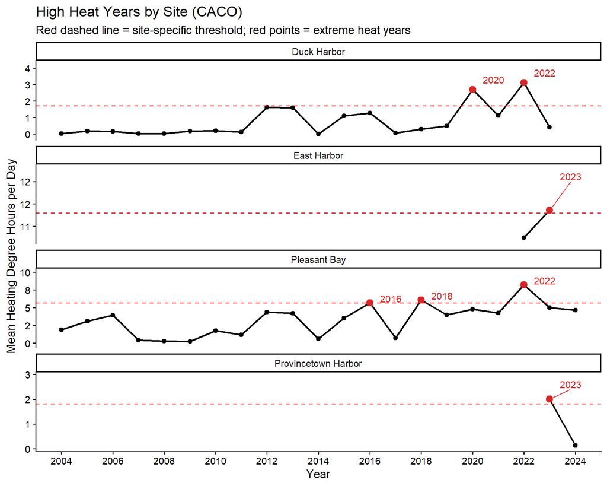

Extreme heat years (HDH above 90th percentile) at each long-term site in CACO.

| Site | Extreme heat years |
| --- | --- |
| Duck Harbor | 2020, 2022 |
| East Harbor | 2023 |
| Pleasant Bay | 2016, 2018, 2022 |
| Provincetown Harbor | 2023 |

## Reduced Cooling Years

On the flip side of heat degree hours, we can look at the mean cooling degree hours across CACO. In this context, more negative CDH values represents greater cooling below the temperature threshold at each site. This represents periods of potential relief for eelgrass meadows.

The table below lists the years at each long term monitoring site when cooling degree hours were exceptionally low (i.e, CDH above the 90th percentile for that site). Extreme low cooling years give us insight when thermal relief was lowest that could limit recovery from thermal stress events.

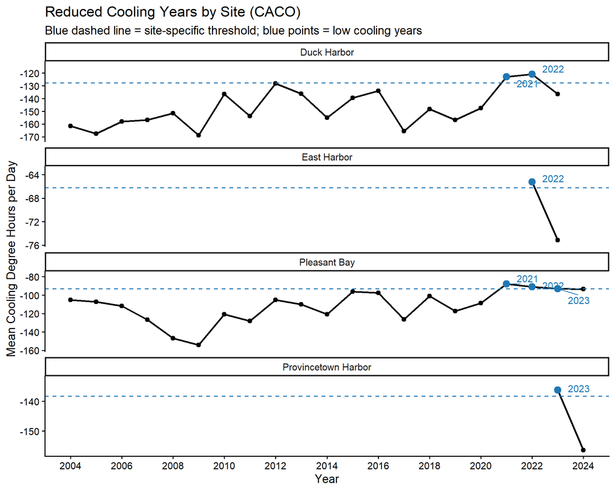

Extreme low cooling years (CDH above 90th percentile) at each long-term site in CACO.

| Site | Extreme low cooling years |
| --- | --- |
| Duck Harbor | 2021, 2022 |
| East Harbor | 2022 |
| Pleasant Bay | 2021, 2022, 2023 |
| Provincetown Harbor | 2023 |

## Stress Years (Combined Heat and low Cooling)

Now we look at where the years of extreme heat and low cooling intersect. Compounded we defined these as “stress years” at the site.

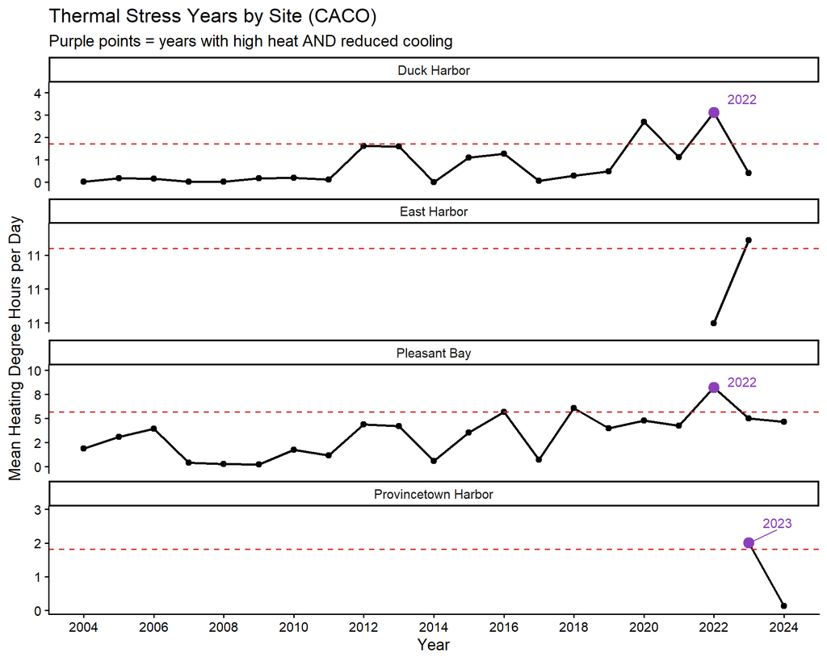

Stress years (purple points) are years when mean CDH **and** mean HDH exceeded the site-specific 90th percentile threshold, inidicating compounded stress.

Double‑stress years (high heat & reduced cooling) at each long‑term site in CACO.

| Site | Double‑stress years |
| --- | --- |
| Duck Harbor | 2022 |
| Pleasant Bay | 2022 |
| Provincetown Harbor | 2023 |

## How does Park Compare Across the Region?

Not all thermal stress at each seagrass monitoring site looks the same. Here we divide the eelgrass meadows into four thermal regimes based on k cluster means:

- **Episodic Heatwave**: Sites with infrequent, but intense heat events
- **Highly Stressed**: Sites with frequent and prolonged heat events
- **Low Exposure**: Sites with infrequent and limited time above thermal threshold
- **Chronic Warming**: Sites with frequent heat events that are not prolonged (pulsing)

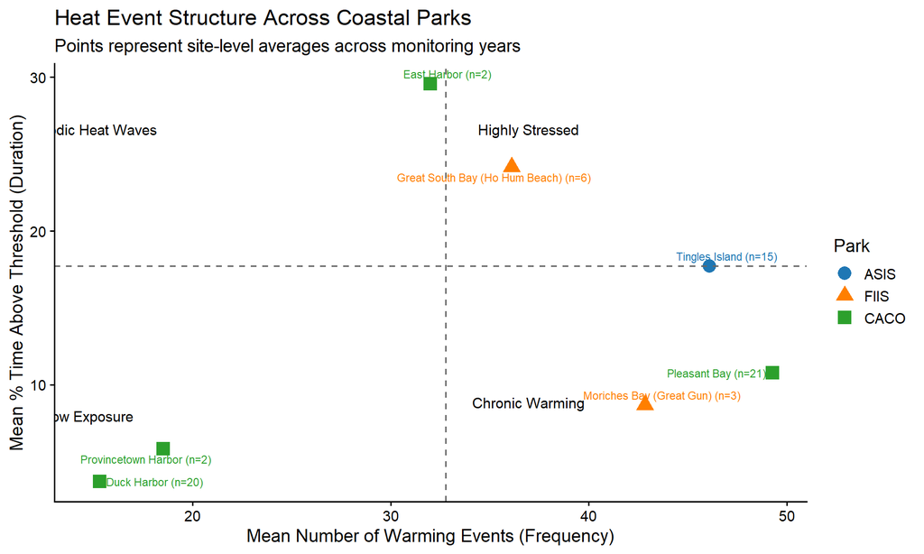

Heat event structure across three coastal National Park Service units (CACO, ASIS, FIIS). Each point represents a site‑level average of the mean number of warming events per year (frequency) and the mean percentage of time above the thermal threshold (duration). Dashed lines divide the figure into four interpretive thermal regimes. Labels show the average number of monitoring years contributing to each site‑level estimate.

FIIS sites fall between these two extremes. Heat‑stress conditions vary widely across the park, depending on where each site is located. For example, Moriches Bay shows short, frequent warming events, while the Great South Bay transect experiences longer or more sustained heat episodes. This mix reflects the diversity of habitats and local conditions across Fire Island.

These results show us that sites across the regional scale experience different heat stress conditions and even sites within the same park respond in different ways. This raises an important questions **how are some of the most chronically stressed sites, like Moriches Bay, Pleasant Bay, and Tingles Island,still able to support eelgrass populations**.